# Assignment #2

Deep Learning / Fall 1398, Iran University of Science and Technology

**Please pay attention to these notes:**

- **Assignment Due:** 1398/9/23 23:59
- If you need any additional information, please review the assignment page on the course website.
- We always recommend co-operation and discussion in groups for assignments. However, each student has to finish all the questions by himself/herself. If our matching system identifies any sort of copying, you'll be responsible for consequences. So, please mention his/her name if you have a team-mate.
- Students who audit this course should submit their assignments like other students to be qualified for attending the rest of the sessions.
- Finding any sort of copying will zero down that assignment grade and also will be counted as two negative assignment for your final score.
- When you are ready to submit, please follow the instructions at the end of this notebook.
- If you have any questions about this assignment, feel free to drop us a line. You may also post your questions on the course Forum page.
- You must run this notebook on Google Colab platform, it depends on Google Colab VM for some of its dependencies.
- **Before starting to work on the assignment Please fill your name in the next section *AND Remember to RUN the cell.***

Assignment Page:

Course Forum: https://groups.google.com/forum/#!forum/dl981/

Fill your information here & run the cell

```python
#@title Enter your information & "RUN the cell!!" { run: "auto" }
student_id =  95521396#@param {type:"integer"}
student_name = "Danial Kamali" #@param {type:"string"}
Your_Github_account_Email = "daniel.kamali@yahoo.com" #@param {type:"string"}

print("your student id:", student_id)
print("your name:", student_name)


from pathlib import Path

ASSIGNMENT_PATH = Path('asg02')
ASSIGNMENT_PATH.mkdir(parents=True, exist_ok=True)
```

```
your student id: 95521396
your name: Danial Kamali
```

# 1. Special Bus Line

Consider the public transport bus service. It has many gates on roads in the city and a particular lane for bus transportation.

This lane is also used for the transportation of emergency vehicles like ambulances, police cars and fire trucks, and private cars are banned from using it.

Your task is to create a system to classify these two classes of vehicles.

### Dataset

In this task, you should build your dataset based on an arbitrary approach. Of course, we suggest having a look at [this](https://forums.fast.ai/t/tips-for-building-large-image-datasets/26688) link if you do not have any idea about making the dataset.

Please explain your dataset making method.

### Implementation

You can use from Keras in this assignment.

Preprocess your data in this cell.

```python
# from google.colab import drive
# drive.mount('/content/drive')
```

```python
!pip install google_images_download
import cv2
!mkdir ./images/
!mkdir ./training/
!mkdir ./test/
!mkdir ./validation/
!mkdir ./training/allowed
!mkdir ./training/not_allowed
!mkdir ./test/allowed
!mkdir ./test/not_allowed
!mkdir ./validation/allowed
!mkdir ./validation/not_allowed
```

[output not shown]

```python
!apt update
!apt install chromium-chromedriver
!cp /usr/lib/chromium-browser/chromedriver /usr/bin
```

[output not shown]

[output cut: 12 more lines]

[output not shown]

```python
# !pip install tensorflow-gpu
```

```python
from google_images_download import google_images_download   #importing the library

response = google_images_download.googleimagesdownload()   #class instantiation

arguments = {"keywords":"bus,police car ,ambulance,fire truck","limit":100,"format":"jpg","image_directory":"allowed","size":">800*600","chromedriver":'/usr/lib/chromium-browser/chromedriver'}   #creating list of arguments

bus_paths = response.download(arguments)   #passing the arguments to the function
```

```
Item no.: 1 --> Item name = bus
Evaluating...
Starting Download...
Completed Image ====> 1.CTY-BUSING23-5.JPG
Completed Image ====> 2.DlsmI_KWwAA5N8_.0.jpg
Completed Image ====> 3.LT_471_%28LTZ_1471%29_Arriva_London_New_Routemaster_%2819522859218%29.jpg
Completed Image ====> 4.wikicommonsm42.0.jpg
Completed Image ====> 5.Transpo_UTA-541063240.jpg
Completed Image ====> 6.RTR3CHPW.jpg
Completed Image ====> 7.home-ss-1-1024x678.jpg
Completed Image ====> 8.tcapsbus.jpg
Completed Image ====> 9.20190917dsElizabethForwardBusLocal03-2-1568804563.jpg
Completed Image ====> 10.190929_gma_gonzalez1_hpMain_16x9_992.jpg
Completed Image ====> 11.BYD-K7M-electric-bus.jpg
Completed Image ====> 12.tata-ultra-urban-9-9-electric-ac-bus.jpg
Completed Image ====> 13.Fall-Buses-2019.jpg
URLError on an image...trying next one... Error: HTTP Error 403: Forbidden - Reason:2
Completed Image ====> 14.bus%20line.JPG
Completed Image ====> 15.TransMio_de_Villa_Nueva_GT.jpg
Completed Image ====> 16.fourlinks_yellowschoolbuses-970x710.jpg
Completed Image ====> 17.638fdc95-f67a-4ed3-9cd6-116bd350849b-SchoolBus4.JPG
Completed Image ====> 18.IMG_9589.JPG
Completed Image ====> 19.3ee51851-9cb4-424a-979b-6b178aa94c68-Leon_County_Schools_Busses_081319_TS_243.JPG
Completed Image ====> 20.tour_img-1634064-148.jpg
Wrong image format returned. Skipping...
Completed Image ====> 21.ZD3TK65C2ZCBBLNYPYQ7VREVGA.jpg
Completed Image ====> 22.PortAuthorityPittsburghBus.jpg
Completed Image ====> 23.charter-bus-rental.jpg
Completed Image ====> 24.bus_pic_35-4e9jd5.jpg
Completed Image ====> 25.bus-THUMB.jpg
Completed Image ====> 26.img_2952.jpg
Completed Image ====> 27.rodriguez_bus_service_photo.jpg
Completed Image ====> 28.3915a785-c134-4601-8d1a-65f4d3ee899c-large16x9_Busscreengrab.JPG
Completed Image ====> 29.04_MANLionsCoachAward_AndereContent_Header_Startseite_1500x1500.jpg
Completed Image ====> 30.transitApp1029.jpg
Completed Image ====> 31.facebook.jpg
Completed Image ====> 32.LIONC-Brand-e1568412722237.jpg
Completed Image ====> 33.Viajar-en-autobus-en-Rusia-Imagen-destacada.jpg
Wrong image format returned. Skipping...
Wrong image format returned. Skipping...
```

[output cut: 283 more lines]

```
Completed Image ====> 74.FR024-38_08_900__93098.1541008507.jpg
Completed Image ====> 75.5d0be72e20e82.image.jpg
Completed Image ====> 76.fire_truck.jpg
Completed Image ====> 77.5583456-big-red-fire-truck-isolated-on-white.jpg
Completed Image ====> 78.2-1523292275664@2x.jpg
Completed Image ====> 79.91E5uxrTi1L._AC_SL1500_.jpg
Completed Image ====> 80.f-n-Fre-FireTrucks_110719.jpg
Completed Image ====> 81.avenger-crt-web.jpg
Completed Image ====> 82.DF1D62C638BD668CBAE9046C038628A5.jpg
Completed Image ====> 83.KL40027_800x.jpg


Unfortunately all 100 could not be downloaded because some images were not downloadable. 83 is all we got for this search filter!

Errors: 17
```

```python
response = google_images_download.googleimagesdownload()   #class instantiation
arguments1 = {"keywords":"car in street","limit":300,"image_directory":"not_allowed","format":"jpg","type":"photo","chromedriver":'/usr/lib/chromium-browser/chromedriver'}   #creating list of arguments

car_paths = response.download(arguments1)   #passing the arguments to the function
```

```
Item no.: 1 --> Item name = car in street
Evaluating...
Getting you a lot of images. This may take a few moments...
Reached end of Page.
Starting Download...
Completed Image ====> 1.how_far_away_must_you_park_from_a_driveway_800x450-1.jpg
Completed Image ====> 2.62bddd2a-89ab-11e7-8a03-f21d91374892-780x429.jpg
Completed Image ====> 3.JS137424394.jpg
Completed Image ====> 4.Google_Street_View_Car_in_Aranjuez.jpg
Completed Image ====> 5.drivers-park-car-in-middle-of-street-to-avoid-alternate-side-tickets.jpg
Completed Image ====> 6.many-car-street-15244647.jpg
Completed Image ====> 7.18502939_web1_190913-sfe-tenderloincollision-001.jpg
URLError on an image...trying next one... Error: HTTP Error 404: Not Found
Completed Image ====> 8.20180808%20-%20Zipcar%20Carshare%20Pilot%20N12th%20and%20Bedford%20BK%20-IMG_4698%20-%20lo%20res.jpg
Completed Image ====> 9.Google_Street_View_Car_in_Honolulu.jpg
Completed Image ====> 10.new_car_old_street.jpg
Completed Image ====> 11.191105_kabc_hit_run1_hpMain_16x9_992.jpg
Completed Image ====> 12.7034279-car-street-city-photo.jpg
Completed Image ====> 13.12-1.jpg
Completed Image ====> 14.PAY-JS113491462.jpg
Completed Image ====> 15.lowest_street_car_01.jpg
Completed Image ====> 16.NJEMT01.jpg
Completed Image ====> 17.a-line-of-cars-parked-in-the-median-on-south-broad-street-emma-lee-whyy-2.original-768x432.jpg
Completed Image ====> 18.60232-640x360-parking-london-640.jpg
Completed Image ====> 19.RTX6EEZ7.jpg
Completed Image ====> 20.google-street-view-car-1.jpg
Completed Image ====> 21.parking-offence-UK-967994.jpg
Completed Image ====> 22.thumbnail.jpg
Completed Image ====> 23.car-speeding-down-street-2822355.jpg
Completed Image ====> 24.gettyimages-659266224.jpg
Completed Image ====> 25.110447-jpg.jpg
Completed Image ====> 26.CIMG1491.JPG
Completed Image ====> 27.GettyImages-672708315-5bd707f9c9e77c00510eb0bf.jpg
Completed Image ====> 28.maxresdefault.jpg
Completed Image ====> 29.car-seat-street1-ht-ml-190115_hpMain_16x9_992.jpg
Completed Image ====> 30.6927055-lamborghini-car-parking-street-sunset.jpg
Completed Image ====> 31.LOW-L-pedestrian1.jpg
Completed Image ====> 32.Parking%20Guide.jpg
Completed Image ====> 33.220px-Google_Street_View_2018_02.jpg
Completed Image ====> 34.Dog-damage-2.jpg
```

[output cut: 302 more lines]

```
Completed Image ====> 289.2022_01.jpg
Completed Image ====> 290.nmraSBlead.jpg
Completed Image ====> 291.google-main3.jpg
Completed Image ====> 292.1601695083.jpg
Completed Image ====> 293.IMG_6837.jpg
Completed Image ====> 294.21537656524.jpg
Completed Image ====> 295.larpenteur-avenue-crash.jpg
Wrong image format returned. Skipping...
Completed Image ====> 296.1200px-San_Francisco_Cable_Car_13.jpg
Completed Image ====> 297.maxresdefault.jpg
Completed Image ====> 298.JunkVehicleBuyer13-624x429.jpg
Completed Image ====> 299.gen1-rome.jpg
Completed Image ====> 300.t_aa0574e43bf74ea6bf0bf7e0388571ac_name_file_1280x720_2000_v3_1_.jpg

Errors: 50
```

```python
# !rm /content/validation/not_allowed/*
# !rm /content/training/not_allowed/*
```

```python
import os
import shutil

# path
# List files and directories
# in 'C:/Users/Rajnish/Desktop/GeeksforGeeks'
def split_data(dir):
  base_dir = "/content/downloads/"+dir+"/"
  training_dir = "/content/training/"+dir+"/"
  validation_dir = "/content/validation/"+dir+"/"
  test_dir = "/content/test/"+dir+"/"
  images = os.listdir(base_dir)
  images_count = len(images)
  training_size = int(images_count*0.6)
  validation_size = int(images_count*0.8)
  test_size = int(images_count*1)
  cnt = 0
  for image in images:
    if(cnt<=training_size):
      shutil.move(base_dir+image, training_dir+dir+str(cnt)+".jpg")
    elif(cnt<=validation_size):
      shutil.move(base_dir+image, validation_dir+dir+str(cnt)+".jpg")
    else:
      shutil.move(base_dir+image, test_dir+dir+str(cnt)+".jpg")
    cnt += 1

  return training_size,test_size,validation_size

training_size1,test_size1,validation_size1 = split_data('allowed')
training_size2,test_size2,validation_size2 = split_data('not_allowed')

training_size = training_size1 + training_size2
test_size = test_size1 + test_size2
validation_size = validation_size1 + validation_size2
```

```python
!pip install piexif
from os import listdir
from PIL import Image
import piexif
import cv2
def check(base_dir):
  for filename in listdir(base_dir):
    if filename.endswith('.jpg'):
      try:
        # print(base_dir+filename)
        # piexif.remove(base_dir+filename)
        img = Image.open(base_dir+filename) # open the image file
        img.verify() # verify that it is, in fact an image
        image =  cv2.imread(base_dir+filename)
        resized_image =  cv2.resize(image,(150,150),interpolation = cv2.INTER_AREA)
        os.remove(base_dir+filename)
        cv2.imwrite(base_dir+filename,resized_image)
        # imResize = img.resize((200,200), Image.ANTIALIAS)
        # os.remove(base_dir+filename)
        # imResize.save(base_dir+filename, 'JPEG', quality=90)

      except (IOError, SyntaxError) as e:
        os.remove(base_dir+filename)

check("/content/downloads/allowed/")
check("/content/downloads/not_allowed/")
check("/content/training/allowed/")
check("/content/training/not_allowed/")
check("/content/test/allowed/")
check("/content/test/not_allowed/")
check("/content/validation/allowed/")
check("/content/validation/not_allowed/")
```

```python
from tensorflow.keras.preprocessing.image import ImageDataGenerator

train_datagen = ImageDataGenerator(
    rotation_range=30,
    width_shift_range=0.2,
    height_shift_range=0.2,
    rescale=1./255,
    shear_range=0.2,
    zoom_range=0.2,
    horizontal_flip=True)

test_datagen = ImageDataGenerator(rescale=1./255)

train_generator = train_datagen.flow_from_directory(
    'training',
    target_size=(150, 150),
    batch_size=20,
    class_mode='binary')

validation_generator = test_datagen.flow_from_directory(
    'validation',
    target_size=(150, 150),
    batch_size=20,
    class_mode='binary')


test_generator = test_datagen.flow_from_directory(
    'test',
    target_size=(150, 150),
    batch_size=20,
    class_mode='binary')
```

```
Found 474 images belonging to 2 classes.
Found 156 images belonging to 2 classes.
Found 157 images belonging to 2 classes.
```

```python
from keras.optimizers import Adam
from keras import backend as K

def recall(y_true, y_pred):

    true_positives = K.sum(K.round(K.clip(y_true * y_pred, 0, 1)))
    possible_positives = K.sum(K.round(K.clip(y_true, 0, 1)))
    recall = true_positives / (possible_positives + K.epsilon())
    return recall


def precision(y_true, y_pred):

    true_positives = K.sum(K.round(K.clip(y_true * y_pred, 0, 1)))
    predicted_positives = K.sum(K.round(K.clip(y_pred, 0, 1)))
    precision = true_positives / (predicted_positives + K.epsilon())
    return precision


def f1(y_true, y_pred):
    p = precision(y_true, y_pred)
    r = recall(y_true, y_pred)
    return 2 * ((p * r) / (p + r))
```

```python
from keras.preprocessing.image import ImageDataGenerator
from keras.applications import VGG16
from keras import models
from keras import layers
from keras.applications.imagenet_utils import preprocess_input
from keras import optimizers
from keras import metrics

model = models.Sequential()

model.add(layers.Conv2D(32, (3, 3), activation='relu', input_shape=(150, 150, 3)))
model.add(layers.MaxPooling2D((2, 2)))

model.add(layers.Conv2D(64, (3, 3), activation='relu'))
model.add(layers.MaxPooling2D((2, 2)))

model.add(layers.Conv2D(128, (3, 3), activation='relu'))
model.add(layers.MaxPooling2D((2, 2)))

model.add(layers.Flatten())
model.add(layers.Dense(256, activation='relu'))
model.add(layers.Dropout(0.5))

model.add(layers.Dense(128, activation='relu'))
model.add(layers.Dropout(0.5))
model.add(layers.Dense(64, activation='relu'))
model.add(layers.Dense(1, activation='sigmoid'))

model.compile(loss='binary_crossentropy', optimizer=optimizers.RMSprop(lr=2e-5),
              metrics=["accuracy",f1,recall,precision,metrics.binary_accuracy])
model.summary()
history = model.fit_generator(
      train_generator,
      steps_per_epoch=20,
      epochs=40,
      validation_data=validation_generator,
      validation_steps=50)
```

```
Model: "sequential_3"
_________________________________________________________________
Layer (type)                 Output Shape              Param #
=================================================================
conv2d_7 (Conv2D)            (None, 148, 148, 32)      896
_________________________________________________________________
max_pooling2d_7 (MaxPooling2 (None, 74, 74, 32)        0
_________________________________________________________________
conv2d_8 (Conv2D)            (None, 72, 72, 64)        18496
_________________________________________________________________
max_pooling2d_8 (MaxPooling2 (None, 36, 36, 64)        0
_________________________________________________________________
conv2d_9 (Conv2D)            (None, 34, 34, 128)       73856
_________________________________________________________________
max_pooling2d_9 (MaxPooling2 (None, 17, 17, 128)       0
_________________________________________________________________
flatten_3 (Flatten)          (None, 36992)             0
_________________________________________________________________
dense_9 (Dense)              (None, 256)               9470208
_________________________________________________________________
dropout_5 (Dropout)          (None, 256)               0
_________________________________________________________________
dense_10 (Dense)             (None, 128)               32896
_________________________________________________________________
dropout_6 (Dropout)          (None, 128)               0
_________________________________________________________________
dense_11 (Dense)             (None, 64)                8256
_________________________________________________________________
dense_12 (Dense)             (None, 1)                 65
=================================================================
Total params: 9,604,673
Trainable params: 9,604,673
Non-trainable params: 0
_________________________________________________________________
```

```
loss : 0.5940499567681816
acc : 0.7070063736028732
f1 : 0.5979216277219688
recall : 0.5745222993717072
precision : 0.6495046061315354
binary_accuracy : 0.7070063736028732
```

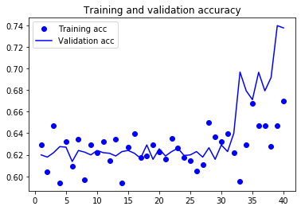

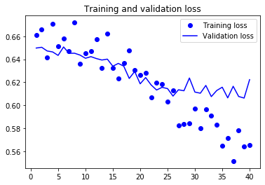

```python
scores = model.evaluate_generator(test_generator)
for i in range(len(scores)):
  print(str(list(model.metrics_names)[i])+" : "+ str(scores[i]))

import matplotlib.pyplot as plt

acc = history.history['acc']
val_acc = history.history['val_acc']
loss = history.history['loss']
val_loss = history.history['val_loss']

epochs = range(1, len(acc) + 1)

plt.plot(epochs, acc, 'bo', label='Training acc')
plt.plot(epochs, val_acc, 'b', label='Validation acc')
plt.title('Training and validation accuracy')
plt.legend()

plt.figure()

plt.plot(epochs, loss, 'bo', label='Training loss')
plt.plot(epochs, val_loss, 'b', label='Validation loss')
plt.title('Training and validation loss')
plt.legend()

plt.show()
```

The metrics were improving so trained it more and result got better so i extend main fit 20 more epochs

```python
# history = model.fit_generator(
#       train_generator,
#       steps_per_epoch=50,
#       epochs=20,
#       validation_data=validation_generator,
#       validation_steps=50)
```

The metrics were still improving so trained it more but results got bad so i commented it

```python
# history = model.fit_generator(
#       train_generator,
#       steps_per_epoch=50,
#       epochs=10,
#       validation_data=validation_generator,
#       validation_steps=50)
```

```python
scores = model.evaluate_generator(test_generator)
print(scores)
for i in range(len(scores)):
  print(str(list(model.metrics_names)[i])+" : "+ str(scores[i]))
print(model.metrics_names)
```

```
[0.5763493051194841, 0.7388535092590721, 0.5407768419593763, 0.4346651298225306, 0.7355171411660066, 0.7388535092590721]
loss : 0.5763493051194841
acc : 0.7388535092590721
f1 : 0.5407768419593763
recall : 0.4346651298225306
precision : 0.7355171411660066
binary_accuracy : 0.7388535092590721
['loss', 'acc', 'f1', 'recall', 'precision', 'binary_accuracy']
```

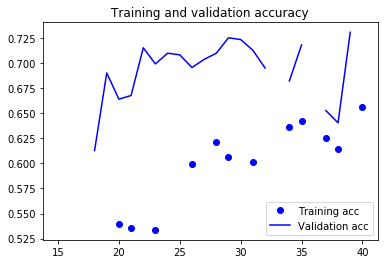

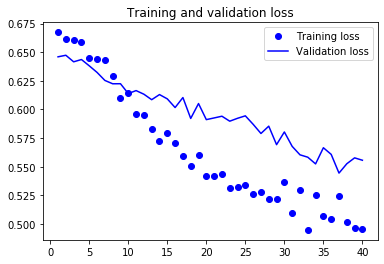

```python
import matplotlib.pyplot as plt

acc = history.history['f1']
val_acc = history.history['val_f1']
loss = history.history['loss']
val_loss = history.history['val_loss']

epochs = range(1, len(acc) + 1)

plt.plot(epochs, acc, 'bo', label='Training acc')
plt.plot(epochs, val_acc, 'b', label='Validation acc')
plt.title('Training and validation accuracy')
plt.legend()

plt.figure()

plt.plot(epochs, loss, 'bo', label='Training loss')
plt.plot(epochs, val_loss, 'b', label='Validation loss')
plt.title('Training and validation loss')
plt.legend()

plt.show()
```

[figure not shown]

```
[[0.]]
```

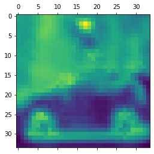

```python
from keras.preprocessing import image
from keras import backend as K
import numpy as np


img = image.load_img('/content/test/not_allowed/not_allowed285.jpg', target_size=(150, 150))
# img = image.load_img('/content/validation/not_allowed/not_allowed196.jpg', target_size=(150, 150))

plt.imshow(img)
plt.show()

x = image.img_to_array(img)
x = np.expand_dims(x, axis=0)
x = preprocess_input(x)
predict = model.predict(x)
print(predict)

output = model.output[:, 0]
conv_layer = model.get_layer(index=4)
grads = K.gradients(output, conv_layer.output)[0]
pooled_grads = K.mean(grads, axis=(0, 1, 2))
iterate = K.function([model.input],[pooled_grads, conv_layer.output[0]])
pooled_grads_value, conv_layer_output_value = iterate([x])
for i in range(64):
  conv_layer_output_value[:, :, i] *= pooled_grads_value[i]
heatmap = np.mean(conv_layer_output_value, axis=-1)

%matplotlib inline
import matplotlib.pyplot as plt

heatmap = np.maximum(heatmap, 0)
heatmap /= np.max(heatmap)
plt.matshow(heatmap)
```

[figure not shown]

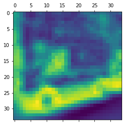

```python
from keras.preprocessing import image
from keras import backend as K
import numpy as np


# img = image.load_img('/content/test/not_allowed/not_allowed285.jpg', target_size=(150, 150))
img = image.load_img('/content/training/allowed/allowed199.jpg', target_size=(150, 150))

x = image.img_to_array(img)
x = np.expand_dims(x, axis=0)
x = preprocess_input(x)

output = model.output[:, 0]
conv_layer = model.get_layer(index=4)
grads = K.gradients(output, conv_layer.output)[0]
pooled_grads = K.mean(grads, axis=(0, 1, 2))
iterate = K.function([model.input],[pooled_grads, conv_layer.output[0]])
pooled_grads_value, conv_layer_output_value = iterate([x])
for i in range(64):
  conv_layer_output_value[:, :, i] *= pooled_grads_value[i]
heatmap = np.mean(conv_layer_output_value, axis=-1)

%matplotlib inline
import matplotlib.pyplot as plt

plt.imshow(img)
plt.show()


heatmap = np.maximum(heatmap, 0)
heatmap /= np.max(heatmap)
plt.matshow(heatmap)
```

Visualize some layers and analyze them.

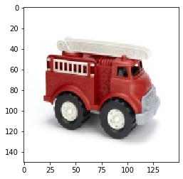

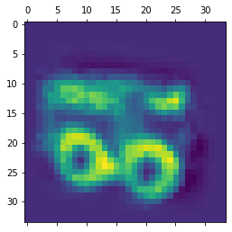

```python
from keras.preprocessing import image
from keras import backend as K
import numpy as np

# img = image.load_img('/content/test/allowed/allowed216.jpg', target_size=(150, 150))
# img = image.load_img('/content/validation/not_allowed/not_allowed207.jpg', target_size=(150, 150))
img = image.load_img('/content/test/allowed/allowed425.jpg', target_size=(150, 150))
output = model.output[:, 0]
conv_layer = model.get_layer(index=4)
grads = K.gradients(output, conv_layer.output)[0]
pooled_grads = K.mean(grads, axis=(0, 1, 2))
iterate = K.function([model.input],[pooled_grads, conv_layer.output[0]])
pooled_grads_value, conv_layer_output_value = iterate([x])
for i in range(64):
  conv_layer_output_value[:, :, i] *= pooled_grads_value[i]
heatmap = np.mean(conv_layer_output_value, axis=-1)

%matplotlib inline
import matplotlib.pyplot as plt

heatmap = np.maximum(heatmap, 0)
heatmap /= np.max(heatmap)

plt.imshow(img)
plt.show()
plt.matshow(heatmap)
```

In above cell is you can see that car edges and tires are most important features for network

```python
from keras.models import Sequential
from keras.layers import Conv2D, MaxPooling2D
from keras.layers import Activation, Dropout, Flatten, Dense
from keras import metrics

model1 = Sequential()
model1.add(Conv2D(32, (3, 3), input_shape=( 150, 150,3)))
model1.add(Activation('relu'))
model1.add(MaxPooling2D(pool_size=(2, 2)))

model1.add(Conv2D(64, (3, 3)))
model1.add(Activation('relu'))
model1.add(MaxPooling2D(pool_size=(2, 2)))

model1.add(Conv2D(64, (3, 3)))
model1.add(Activation('relu'))
model1.add(MaxPooling2D(pool_size=(2, 2)))

model1.add(Flatten())
model1.add(Dropout(0.5))
model1.add(Dense(64))
model1.add(Activation('relu'))
model1.add(Dropout(0.5))
model1.add(Dense(32))
model1.add(Activation('relu'))
model1.add(Dense(1))
model1.add(Activation('sigmoid'))


model1.compile(loss='binary_crossentropy', optimizer=optimizers.RMSprop(lr=2e-5),
              metrics=["accuracy",f1,recall,precision,metrics.binary_accuracy])

history1 = model1.fit_generator(
      train_generator,
      steps_per_epoch=200,
      epochs=50,
      validation_data=validation_generator,
      validation_steps=50)
```

```python
scores = model1.evaluate_generator(test_generator)
print(scores)
for i in range(len(scores)):
  print(str(list(model1.metrics_names)[i])+" : "+ str(scores[i]))
print(model1.metrics_names)
```

```
[0.5019137665724299, 0.7770700674907417, 0.618481225268856, 0.536447282050066, 0.753412198109232, 0.7770700674907417]
loss : 0.5019137665724299
acc : 0.7770700674907417
f1 : 0.618481225268856
recall : 0.536447282050066
precision : 0.753412198109232
binary_accuracy : 0.7770700674907417
['loss', 'acc', 'f1', 'recall', 'precision', 'binary_accuracy']
```

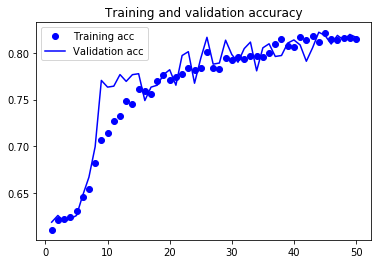

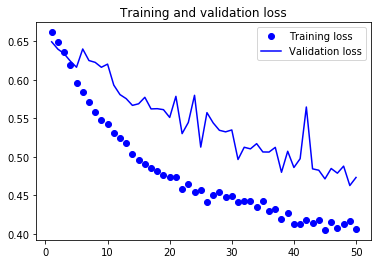

```python
import matplotlib.pyplot as plt

acc = history1.history['acc']
val_acc = history1.history['val_acc']

# f1 = history1.history['f1']
# val_f1 = history1.history['val_f1']

loss = history1.history['loss']
val_loss = history1.history['val_loss']

epochs = range(1, len(acc) + 1)


# plt.plot(epochs, f1, 'bo', label='Training f1')
# plt.plot(epochs, val_f1, 'b', label='Validation f1')
# plt.title('Training and validation accuracy')
# plt.legend()

# plt.figure()

plt.plot(epochs, acc, 'bo', label='Training acc')
plt.plot(epochs, val_acc, 'b', label='Validation acc')
plt.title('Training and validation accuracy')
plt.legend()

plt.figure()

plt.plot(epochs, loss, 'bo', label='Training loss')
plt.plot(epochs, val_loss, 'b', label='Validation loss')
plt.title('Training and validation loss')
plt.legend()

plt.show()
```

```python
model1.save('my_model.h5')
```

```python
history2 = model1.fit_generator(
      train_generator,
      steps_per_epoch=100,
      epochs=20,
      validation_data=validation_generator,
      validation_steps=50)
```

```python
scores = model1.evaluate_generator(test_generator)
print(scores)
for i in range(len(scores)):
  print(str(list(model1.metrics_names)[i])+" : "+ str(scores[i]))
print(model1.metrics_names)
```

```
[0.5335588451403721, 0.7707006373223225, 0.6188670096883349, 0.5849256963486884, 0.7201091973644913, 0.7707006373223225]
loss : 0.5335588451403721
acc : 0.7707006373223225
f1 : 0.6188670096883349
recall : 0.5849256963486884
precision : 0.7201091973644913
binary_accuracy : 0.7707006373223225
['loss', 'acc', 'f1', 'recall', 'precision', 'binary_accuracy']
```

```python
history2 = model1.fit_generator(
      train_generator,
      steps_per_epoch=10,
      epochs=20,
      validation_data=validation_generator,
      validation_steps=50)
```

```python
scores = model1.evaluate_generator(test_generator)
print(scores)
for i in range(len(scores)):
  print(str(list(model1.metrics_names)[i])+" : "+ str(scores[i]))
print(model1.metrics_names)
```

```
[0.526388717115305, 0.7707006430170339, 0.6657754790251422, 0.64897381803792, 0.7134263515472412, 0.7707006430170339]
loss : 0.526388717115305
acc : 0.7707006430170339
f1 : 0.6657754790251422
recall : 0.64897381803792
precision : 0.7134263515472412
binary_accuracy : 0.7707006430170339
['loss', 'acc', 'f1', 'recall', 'precision', 'binary_accuracy']
```

```python
from keras.preprocessing import image
from keras import backend as K
import numpy as np

from keras.applications.imagenet_utils import preprocess_input
scores = model.evaluate_generator(test_generator)


# img = image.load_img('/content/test/allowed/allowed216.jpg', target_size=(150, 150))
# img = image.load_img('/content/validation/not_allowed/not_allowed207.jpg', target_size=(150, 150))
img = image.load_img('/content/test/allowed/allowed425.jpg', target_size=(150, 150))

x = image.img_to_array(img)
x = np.expand_dims(x, axis=0)
x = preprocess_input(x)
predict = model1.predict(x)

print(predict)

output = model1.output[:, 0]
conv_layer = model1.get_layer(index=4)
grads = K.gradients(output, conv_layer.output)[0]
pooled_grads = K.mean(grads, axis=(0, 1, 2))
iterate = K.function([model1.input],[pooled_grads, conv_layer.output[0]])
pooled_grads_value, conv_layer_output_value = iterate([x])
for i in range(64):
  conv_layer_output_value[:, :, i] *= pooled_grads_value[i]
heatmap = np.mean(conv_layer_output_value, axis=-1)

%matplotlib inline
import matplotlib.pyplot as plt

heatmap = np.maximum(heatmap, 0)
heatmap /= np.max(heatmap)

plt.imshow(img)
plt.show()
plt.matshow(heatmap)
```

[output not shown]

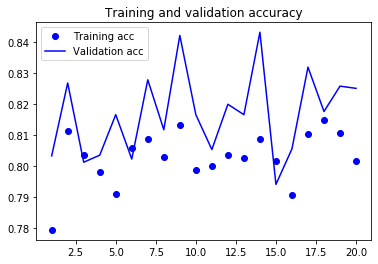

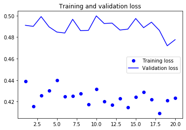

```python
import matplotlib.pyplot as plt

acc = history2.history['acc']
val_acc = history2.history['val_acc']

# f1 = history1.history['f1']
# val_f1 = history1.history['val_f1']

loss = history2.history['loss']
val_loss = history2.history['val_loss']

epochs = range(1, len(acc) + 1)


# plt.plot(epochs, f1, 'bo', label='Training f1')
# plt.plot(epochs, val_f1, 'b', label='Validation f1')
# plt.title('Training and validation accuracy')
# plt.legend()

# plt.figure()

plt.plot(epochs, acc, 'bo', label='Training acc')
plt.plot(epochs, val_acc, 'b', label='Validation acc')
plt.title('Training and validation accuracy')
plt.legend()

plt.figure()

plt.plot(epochs, loss, 'bo', label='Training loss')
plt.plot(epochs, val_loss, 'b', label='Validation loss')
plt.title('Training and validation loss')
plt.legend()

plt.show()
```

[figure not shown]

```
[[0.]]
Colors are so similar to police cars
```

[figure not shown]

```
[[0.]]
```

```python
img = image.load_img('/content/test/not_allowed/not_allowed261.jpg', target_size=(150, 150))
plt.imshow(img)
plt.show()

x = image.img_to_array(img)
x = np.expand_dims(x, axis=0)
x = preprocess_input(x)
predict = model1.predict(x)
print(predict)
print("Colors are so similar to police cars ")
img = image.load_img('/content/test/allowed/allowed394.jpg', target_size=(150, 150))
plt.imshow(img)
plt.show()

x = image.img_to_array(img)
x = np.expand_dims(x, axis=0)
x = preprocess_input(x)
predict = model.predict(x)
print(predict)
```

As you can see in above some images aren't satisfing their purpose

```python
from keras.models import Sequential
from keras.layers import Conv2D, MaxPooling2D
from keras.layers import Activation, Dropout, Flatten, Dense
from keras import metrics

model2 = Sequential()
model2.add(Conv2D(32, (3, 3), input_shape=( 150, 150,3)))
model2.add(Activation('relu'))
model2.add(MaxPooling2D(pool_size=(2, 2)))

model2.add(Conv2D(64, (3, 3)))
model2.add(Activation('relu'))
model2.add(MaxPooling2D(pool_size=(2, 2)))

model2.add(Conv2D(128, (3, 3)))
model2.add(Activation('relu'))
model2.add(MaxPooling2D(pool_size=(2, 2)))

model2.add(Flatten())
model2.add(Dropout(0.5))
model2.add(Dense(32))
model2.add(Activation('relu'))
model2.add(Dense(1))
model2.add(Activation('sigmoid'))


model2.compile(loss='binary_crossentropy', optimizer=optimizers.RMSprop(lr=2e-5),
              metrics=["accuracy",f1,recall,precision,metrics.binary_accuracy])

history11= model2.fit_generator(
      train_generator,
      steps_per_epoch=100,
      epochs=50,
      validation_data=validation_generator,
      validation_steps=50)
```

```
loss : 0.46015121526778885
acc : 0.7579617826801957
f1 : 0.6541415312487608
recall : 0.6403479762138076
precision : 0.731808532195486
binary_accuracy : 0.7579617826801957
```

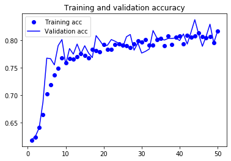

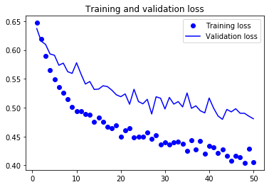

```python
scores = model2.evaluate_generator(test_generator)
for i in range(len(scores)):
  print(str(list(model2.metrics_names)[i])+" : "+ str(scores[i]))
import matplotlib.pyplot as plt

acc = history11.history['acc']
val_acc = history11.history['val_acc']

# f1 = history1.history['f1']
# val_f1 = history1.history['val_f1']

loss = history11.history['loss']
val_loss = history11.history['val_loss']

epochs = range(1, len(acc) + 1)


plt.plot(epochs, acc, 'bo', label='Training acc')
plt.plot(epochs, val_acc, 'b', label='Validation acc')
plt.title('Training and validation accuracy')
plt.legend()

plt.figure()

plt.plot(epochs, loss, 'bo', label='Training loss')
plt.plot(epochs, val_loss, 'b', label='Validation loss')
plt.title('Training and validation loss')
plt.legend()

plt.show()
```

## **Therfore better method to use is to train model to classify each type of car or fire truck .. and bus and then classify and get result based on that.**

```python
from keras.preprocessing.image import ImageDataGenerator
from keras.applications import VGG16
from keras import models
from keras import layers
from keras.applications.imagenet_utils import preprocess_input
from keras import optimizers

conv_base = VGG16(weights='imagenet', include_top=False, input_shape=(150, 150, 3))

model3 = models.Sequential()
model3.add(conv_base)
model3.add(layers.Flatten())
model3.add(layers.Dense(64, activation='relu'))
model3.add(layers.Dense(1, activation='sigmoid'))


model3.compile(loss='binary_crossentropy', optimizer=optimizers.RMSprop(lr=2e-5),
              metrics=["accuracy",f1,recall,precision,metrics.binary_accuracy])

history3= model3.fit_generator(
      train_generator,
      steps_per_epoch=10,
      epochs=20,
      validation_data=validation_generator,
      validation_steps=50)
```

```
loss : 0.4861594506889392
acc : 0.7961783409118652
f1 : 0.7569954550949631
recall : 0.8708421789157162
precision : 0.692407030778326
binary_accuracy : 0.7961783409118652
```

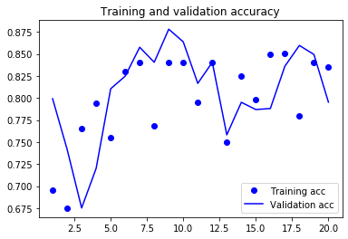

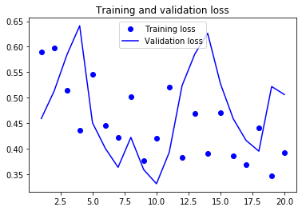

```python
scores = model3.evaluate_generator(test_generator)
for i in range(len(scores)):
  print(str(list(model3.metrics_names)[i])+" : "+ str(scores[i]))
import matplotlib.pyplot as plt

acc = history3.history['acc']
val_acc = history3.history['val_acc']

# f1 = history1.history['f1']
# val_f1 = history1.history['val_f1']

loss = history3.history['loss']
val_loss = history3.history['val_loss']

epochs = range(1, len(acc) + 1)


plt.plot(epochs, acc, 'bo', label='Training acc')
plt.plot(epochs, val_acc, 'b', label='Validation acc')
plt.title('Training and validation accuracy')
plt.legend()

plt.figure()

plt.plot(epochs, loss, 'bo', label='Training loss')
plt.plot(epochs, val_loss, 'b', label='Validation loss')
plt.title('Training and validation loss')
plt.legend()

plt.show()
```

```python
from keras.preprocessing.image import ImageDataGenerator
from keras.applications import VGG16
from keras import models
from keras import layers
from keras.applications.imagenet_utils import preprocess_input
from keras import optimizers

conv_base = VGG16(weights='imagenet', include_top=False, input_shape=(150, 150, 3))

model4 = models.Sequential()
model4.add(conv_base)
model4.add(layers.Flatten())
model4.add(layers.Dense(64, activation='relu'))
model4.add(layers.Dense(1, activation='sigmoid'))


model4.compile(loss='binary_crossentropy', optimizer=optimizers.RMSprop(lr=2e-5),
              metrics=["accuracy",f1,recall,precision,metrics.binary_accuracy])

history4= model4.fit_generator(
      train_generator,
      steps_per_epoch=10,
      epochs=10,
      validation_data=validation_generator,
      validation_steps=50)
```

my instance got cut in middle of this and it take so much time i ignore it

```python
scores = model4.evaluate_generator(test_generator)
for i in range(len(scores)):
  print(str(list(model3.metrics_names)[i])+" : "+ str(scores[i]))
import matplotlib.pyplot as plt

acc = history4.history['acc']
val_acc = history4.history['val_acc']

# f1 = history1.history['f1']
# val_f1 = history1.history['val_f1']

loss = history4.history['loss']
val_loss = history4.history['val_loss']

epochs = range(1, len(acc) + 1)


plt.plot(epochs, acc, 'bo', label='Training acc')
plt.plot(epochs, val_acc, 'b', label='Validation acc')
plt.title('Training and validation accuracy')
plt.legend()

plt.figure()

plt.plot(epochs, loss, 'bo', label='Training loss')
plt.plot(epochs, val_loss, 'b', label='Validation loss')
plt.title('Training and validation loss')
plt.legend()

plt.show()
```

[output not shown]

Please explain that what type of loss and accuracy you set for training your model and why?

$\color{red}{\text{loss is binary_crossentropy because it's so efficient for binary classification ann accucacy metric is binary_accuracy which their result is about 80 percent accuracy}}$

# Submission

Congratulations! You finished the assignment & you're ready to submit your work. Please follow the instruction:

1. Check and review your answers. Make sure all of the cell outputs are what you want.
2. Select File > Save.
3. Run **Create Submission** cell, It may take several minutes and it may ask you for your credential.
4. Run **Download Submission** cell to obtain your submission as a zip file.
5. Grab downloaded file (`dl_asg02__xx__xx.zip`) and submit it via https://forms.gle/Fb7gvVJHp8RePvo6A.

**Note:** We need your Github token to create (if doesn't exist previously) new repository to store learned model data. Also Google Drive token enables us to download the current notebook & create a submission. If you are interested feel free to check our code.

## Create Submission (Run the cell)

```python
#@title
! pip install -U --quiet PyDrive > /dev/null
! wget -q https://github.com/github/hub/releases/download/v2.10.0/hub-linux-amd64-2.10.0.tgz

import os
import time
import yaml
import json

from google.colab import files
from IPython.display import Javascript
from pydrive.auth import GoogleAuth
from pydrive.drive import GoogleDrive
from google.colab import auth
from oauth2client.client import GoogleCredentials

asg_name = 'assignment_02'
script_save = '''
require(["base/js/namespace"],function(Jupyter) {
    Jupyter.notebook.save_checkpoint();
});
'''
repo_name = 'iust-deep-learning-assignments'
submission_file_name = 'dl_asg02__%s__%s.zip'%(student_id, student_name.lower().replace(' ',  '_'))

! tar xf hub-linux-amd64-2.10.0.tgz
! cd hub-linux-amd64-2.10.0/ && chmod a+x install && ./install
! hub config --global hub.protocol https
! hub config --global user.email "$Your_Github_account_Email"
! hub config --global user.name "$student_name"
! hub api --flat -X GET /user
! hub api -F affiliation=owner -X GET /user/repos > repos.json

repos = json.load(open('repos.json'))
repo_names = [r['name'] for r in repos]
has_repository = repo_name in repo_names
if not has_repository:
  get_ipython().system_raw('! hub api -X POST -F name=%s /user/repos > repo_info.json' % repo_name)
  repo_info = json.load(open('repo_info.json'))
  repo_url = repo_info['clone_url']
else:
  for r in repos:
    if r['name'] == repo_name:
      repo_url = r['clone_url']

stream = open("/root/.config/hub", "r")
token = list(yaml.load_all(stream))[0]['github.com'][0]['oauth_token']
repo_url_with_token = 'https://'+token+"@" +repo_url.split('https://')[1]

! git clone "$repo_url_with_token"
! cp -r "$ASSIGNMENT_PATH" "$repo_name"/
! cd "$repo_name" && git add -A
! cd "$repo_name" && git commit -m "Add assignment 02 results"
! cd "$repo_name" && git push -u origin master

sub_info = {
    'student_id': student_id,
    'student_name': student_name,
    'repo_url': repo_url,
    'asg_dir_contents': os.listdir(str(ASSIGNMENT_PATH)),
    'dateime': str(time.time()),
    'asg_name': asg_name
}
json.dump(sub_info, open('info.json', 'w'))

Javascript(script_save)

auth.authenticate_user()
gauth = GoogleAuth()
gauth.credentials = GoogleCredentials.get_application_default()
drive = GoogleDrive(gauth)
file_id = drive.ListFile({'q':"title='%s.ipynb'"%asg_name}).GetList()[0]['id']
downloaded = drive.CreateFile({'id': file_id})
downloaded.GetContentFile('%s.ipynb'%asg_name)

! jupyter nbconvert --to script "$asg_name".ipynb > /dev/null
! jupyter nbconvert --to html "$asg_name".ipynb > /dev/null
! zip "$submission_file_name" "$asg_name".ipynb "$asg_name".html "$asg_name".txt info.json > /dev/null

print("##########################################")
print("Done! Submisson created, Please download using the bellow cell!")
```

[output not shown]

## Download Submission (Run the cell)

```python
#@title
files.download(submission_file_name)
```

If that cell makes an error when running you can download file dl_asg02_your_struden_id_your_name.zip from left panel and files section by right-clicking on it and choosing download button.

# Special Thanks

Special thanks to Amirhossein Kazemnejad and Kiamehr Razaee for creating the template of deep learning course assignments.